# lab

**Convex and Distributed Optimization Lab**  
**MSIAM — Université Grenoble Alpes — 2018/2019**  
**Lecturers: Jérôme Malick, Yassine Laguel, Sélim Chraibi**

**Authors: Aidan Mannion, Ariel Cohen**

```python
# Automatic reload of local libraries
%load_ext autoreload
%autoreload 2
%reload_ext autoreload
%matplotlib inline
```

> **I. Introduction**  
> **II. The optimization problem**  
> **III. Implementing the solvers**  
> GD (Gradient descent))  
> SGD (Stochastic Gradient Descent))  
> SAGA (Stochastic Average Gradient "Amélioré"))  
> SVRG (Stochastic Variance Reduced Gradient))  
> Comparison  
> **IV. Regularization**  
> **V. Further development**

In this lab, you will implement optimization algorithms that you've studied in class and use them to fit a logistic regression classification model.

You will be implementing a simplified version of [`sklearn.linear_model.LogisticRegression`](https://scikit-learn.org/stable/modules/generated/sklearn.linear_model.LogisticRegression.html).

Part of the work has already been done for you (see the `\lib` folder), so you'll only have to implement the `##### TODO (i) #####` sections of the code. Whenever you complete such a section, we ask you to **copy it in this notebook**. We want you to **only send us a pdf or html export of this notebook** so we won't be able to see your work if it's not in this notebook.

# I. Introduction

We consider the [Student Performance](http://archive.ics.uci.edu/ml/datasets/Student+Performance) dataset. This dataset contains student demographic, social, school-related features, how many classes they've missed, etc.

The goal we give ourselves is to predict whether a student will pass (final grade > 12).

We denote $A \in \mathcal{M}_{n,d}(\mathbb{R})$ the feature matrix, containing $n$ samples with $d$ features, and $b \in \{-1,1\}^n$ the label vector where $-1$ encodes `fail` and $1$ encodes `pass`.

The data has already been preprocessed (yay less work for you 🎉). You can check `\lib\datasets.py` if you're curious, otherwise, you can just use the following to load your dataset:

```python
from lib.datasets import load_student_data

A_train, A_test, b_train, b_test = load_student_data('data/student-mat.csv', split=0.25)
```

As mentioned previously, you're going to implement a simplified version of [`sklearn.linear_model.LogisticRegression`](https://scikit-learn.org/stable/modules/generated/sklearn.linear_model.LogisticRegression.html). So let's first see what the finished product should look like.

**Question:**

- Import [sklearn.linear_model.LogisticRegression](https://scikit-learn.org/stable/modules/generated/sklearn.linear_model.LogisticRegression.html) .
- Create an instance of sklearn's logistic regression classifiers with SAGA as its solver.
- Fit the classifier on the training data and compute the score of the fitted model on the test set.

```python
from sklearn.linear_model import LogisticRegression

sk_logistic = LogisticRegression( solver= 'saga', max_iter= 350).fit(A_train, b_train)
print('training accuracy: {0:0.3f}%'.format(100*sk_logistic.score(A_train, b_train)))
print('testing accuracy: {0:0.3f}%'.format(100*sk_logistic.score(A_test, b_test)))
```

```
training accuracy: 94.932%
testing accuracy: 89.899%
```

# II. The optimization problem

Logistic regression consists in finding the parameter $x \in \mathbb{R}^d$ that best fits: $$ b_i = \begin{cases} \phantom{-}1 \ \textrm{ if }\ \langle a_{i}, x\rangle \ge 0 \\ -1 \ \textrm{ if }\ \langle a_{i}, x\rangle < 0 \end{cases} $$ for all the samples $i$ of the training set (where $a_i$ is the $i^{th}$ column of $A$ and $b_i$ the $i^{th}$ element of $b$). To measure this fit, logistic regression chooses the following loss:

$$ \textrm{LogisticLoss}(b_i, \left\langle a_{i}, x\right\rangle ) = \log \left(1+\exp \left(-b_{i}\left\langle a_{i}, x\right\rangle\right)\right) $$

The corresponding optimization problem we will consider is the following:

Minimization of the empirical risk $f$ of the $L_2$-regularized logistic regression model, on the dataset $(A_{\textrm{train}},b_{\textrm{train}})$: $$ \begin{aligned} \textrm{min}_{x\in \mathbb{R}^d} \ f(x) \ &= \ \textrm{min}_{x\in \mathbb{R}^d} \ \frac{1}{n_{\textrm{train}}} \sum_{i=1}^{n_{\textrm{train}}} f_i(x) \\ &= \ \textrm{min}_{x\in \mathbb{R}^d}\frac{1}{n_{\textrm{train}}} \sum_{i=1}^{n_{\textrm{train}}} \textrm{LogisticLoss}(b_i, \left\langle a_{i}, x\right\rangle ) + \frac{l_2}{2}\|x\|^{2}_2, \end{aligned} $$ where $l_2 \ge 0$ is the $L_2$ regularization coefficient.

To simplify the notation, we'll stop indexing $A$, $b$ and $n$ with "$\textrm{train}$" in the following.

**Question:** $f$ is $\mu$-strongly convex.

- Give a lower bound on $\mu$.
- Complete **TODO (1)** in **\lib\linear_model.py**.

> **Answer:**

> $f$ being $\mu$-strongly convex means that $f-\frac{\mu}{||x||^2}$ is convex.

> The logistic loss can be expressed as $f-\frac{l_2}{||x||^2}$, and we know it is convex, which means that $\mu\geq l_2$, i.e. given that a loss function is convex, adding $L_2$ regularisation means it becomes at least $l_2$-strongly convex.

**Question:** Denote $\lambda_{\max}(AA^T)$ the largest eigenvalue of the real symmetric matrix $AA^T$.

- Prove that $\lambda_{\max}(\nabla^2 f_i) \le \lambda_{\max}\left(\frac{a_i a_i^T}{4} + l_2 I_d\right)$
- Prove that $\lambda_{\max}(a_i a_i^T) \le \|a_i\|^2_2$

> **Answer:**
> - Taking the gradient of $f_i$ gives $$\left(\nabla f_i\right)_k=-b_ia_{ki}\left(1+\exp\{-b_i\langle a_i,x\rangle\}\right)^{-1}\exp\{-b_i\langle a_i,x\rangle\}+l_2x_k\mspace{6mu}\forall k\in\{1,\ldots,d\}$$ and so the Hessian, after some simplification, has the form \begin{eqnarray} (\nabla^2f_i)_{kk} & = & a_{ki}^2\left(\frac{\exp\{-b_i\langle a_i,x\rangle\}}{(1+\exp\{-b_i\langle a_i,x\rangle\})^2}\right)+l_2 \\ (\nabla^2f_i)_{jk} & = & a_{ji}a_{ki}\frac{\exp\{-b_i\langle a_i,x\rangle\}}{(1+\exp\{-b_i\langle a_i,x\rangle\})^2},\mspace{9mu}j\neq k \end{eqnarray} which can be expressed as the matrix $$\nabla^2f_i=\left(\frac{\exp\{-b_i\langle a_i,x\rangle\}}{\left(\exp\{-b_i\langle a_i,x\rangle\}+1\right)^2}\right)a_ia_i^T+l_2I_d$$ Because $-b_i\langle a_i,x\rangle<0$ for any $i$, $$0<\exp\{-b_i\langle a_i,x\rangle\}\leq1\mspace{6mu}\forall i$$ and thus $$0<\frac{\exp\{-b_i\langle a_i,x\rangle\}}{(1+\exp\{-b_i\langle a_i,x\rangle\})^2}\leq\frac{1}{4}$$ so we have the result: $$\nabla^2f_i\preceq\frac{a_ia_i^T}{4}+l_2I_d\mspace{12mu}\Rightarrow\mspace{12mu}\lambda_{\max}(\nabla^2f_i)\leq\lambda_{\max}\left(\frac{a_ia_i^T}{4}+l_2I_d\right)$$
> - Because $a_ia_i^T$ is real and symmetric, we can define its Rayleigh quotient as $$R_{a_ia_i^T}(x)=\frac{\langle a_ia_i^Tx,x\rangle}{\langle x,x\rangle}$$ The min-max theorem tells us that the maximum eigenvalue of a Hermitian matrix $A$ (symmetric in the real case) is given by $$\lambda_{\max}(A)=\max_x\left\{R_A(x):x\neq0\right\}$$ The numerator of the Rayleigh quotient of $a_ia_i^T$ can be simplified as $$\langle a_ia_i^Tx,x\rangle=\langle a_i^T,x\rangle\langle a_i,x\rangle=\langle a_i,x\rangle^2$$ so, letting $x_m$ be the vector satisfying the maximisation condition above, we have $$\lambda_{\max}(a_ia_i^T)=\frac{\langle a_i,x_m\rangle^2}{||x_m||_2^2}$$ By the Cauchy-Schwarz inequality, $$\frac{\langle a_i,x_m\rangle^2}{||x_m||_2^2}\leq||a_i||_2^2$$ which gives us that $$\lambda_{\max}(a_ia_i^T)\leq||a_i||_2^2$$

A consequence of these results is that the $f_i$s and $f$ are all $L$-smooth with $L \le \frac{\max_i\|a_i\|^2_2}{4} + l_2$ and we can therefore use the following value in our implementation:

```
L = 0.25 * max(np.linalg.norm(A,2,axis=1))**2 + self.l2
```

# III. Implementing the solvers

To implement gradient methods, we need an oracle that will compute both batch gradients $\nabla f$ and partial gradients $\nabla f_i$.

**Question:** In the code below, $\nabla f$ has already been implemented.

- Complete **TODO (2)** bellow.
- Add your code to **\lib\linear_model.py**.

```python
def grad(x, i=None):
    '''
    Gradient of the objective function at x.
    If no i is given, grad should return the batch gradient.
    Otherwise, it should return the partial gradient associated the the datapoint (A[i], b[i]).
    '''

    if i is None: # return batch gradient
        output = -b/(1 + np.exp(b*np.dot(A, x)))
        output = sum(np.diag(output))/n @ A
        output += self.l2*x
    else: # return partial gradient associated the datapoint (A[i], b[i])
        output = -(b[i] / (1 + np.exp(b[i] * np.dot(A[i], x) ))) * A[i] + self.l2 * x
        pass
    return output
```

# GD (Gradient descent)

At iteration k of the GD algorithm, the following update is executed:

$$ x_{k+1} \leftarrow x_{k} - \gamma\nabla f(x_k) $$

**Question:**

- What stepsize $\gamma$ ensures the convergence of this algorithm and under what assumptions?
- Complete **TODO (3)** and **TODO (4)**
- Add your code to **\lib\solvers.py**.

> **Answer:**

> Suppose the function $f$ is convex and and differentiable, and $L$-smooth ($\nabla f$ is Lipschitz continuous with constant $L>0$).

> Then, if we run gradient descent for k iterations with a fixed step size $\gamma ≤ 1/L $, it will yield a solution $f^{(k)}$ which satisfies $$f(x^{(k)}) − f(x^∗) ≤ \frac{||x^{(0)} − x^∗||^2_2}{2 \gamma k}$$ where $f(x^∗)$ is the optimal value.

> If we add that $f$ is $\mu$-strongly convex, the gradient descent algorithm will converge linearly for $$\gamma=\frac{2}{\mu+L}$$

```python
def GD(x0, grad, max_iter, n, L, mu):
    '''
    Parameters
    ----------
    x0: array, shape (nb_features,)
        Initialisation of the solver
    grad: function
        Gradient of the objective function
    max_iter: int
        Number of iterations (i.e. number of descent steps). Note that for GD or SVRG,
        one iteration is one epoch i.e, one pass through the data, while for SGD, SAG and SAGA,
        one iteration uses only one data point.
    n: int
        Dataset size
    L: float
        Smoothness constant of the objective function
    mu: float
        Strong convexity constant of the objective function

    Returns
    -------
    x: array, shape (nb_features,)
        final iterate of the solver
    x_tab: array, shape (nb_features, max_iter)
        table of all the iterates
    '''
    stepsize  = 1/L
    x         = x0
    x_tab     = np.copy(x)

    for k in range(max_iter):
        x     = x - stepsize * grad(x)
        x_tab = np.vstack((x_tab, x))

    return x, x_tab
```

**Question:** Run the code below to test your code.

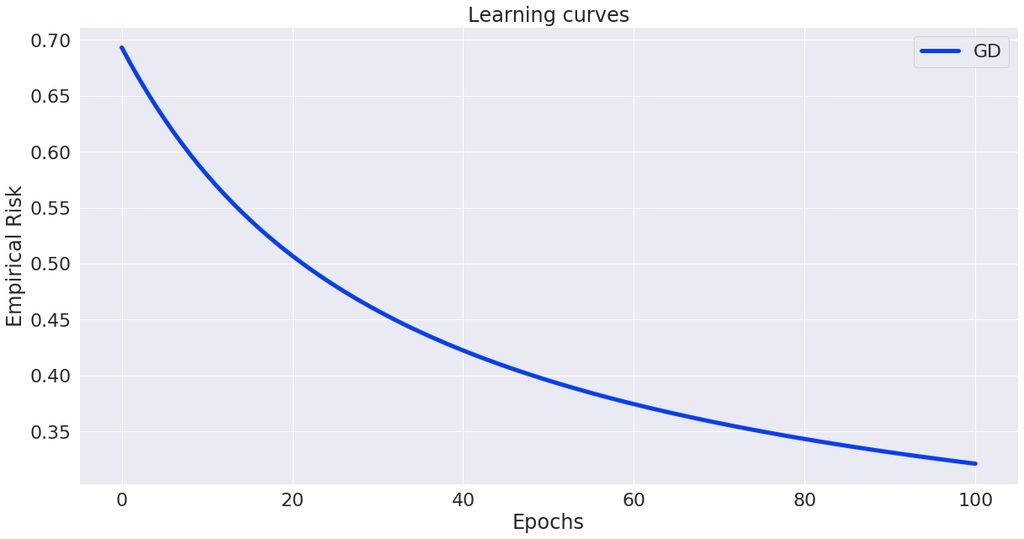

```python
from lib.linear_model import LogisticRegression
from lib.visuals import learning_curve

clf_gd = LogisticRegression(solver='gd', l2=0.01, max_iter=100)
clf_gd.fit(A_train, b_train)

learning_curve(GD=clf_gd)
```

# SGD (Stochastic Gradient Descent)

At iteration k of the SGD algorithm, the following update is executed:

$$ \begin{cases} i \textrm{ chosen randomly in } \{1...n\}\\ x_{k+1} \leftarrow x_{k} - \gamma_k \nabla f_i(x_k) \\ \end{cases} $$

**Question:**

- What stepsize $\gamma_k$ ensures the convergence of this algorithm and under what assumptions?
- Complete **TODO (5)**
- Add your code to **\lib\solvers.py**.

> **Answer**: For the following stepsize results to be valid, we assume that the objective $f$ is strongly convex, the finite sum components $f_i$ are convex and $L$-smooth, and that the sequence $(x_k)_k$ is bounded.

> In order to reduce the noise introduced in the decrease of the loss arising from the randomness in the choice of data point with which to choose the gradient computation, SGD must be run with a vanishing stepsize, i.e. $\gamma_k$ which decreases with every iteration.

> If we assume that for any $k\in\mathbb{N}$: $$\gamma_k<\gamma_{k-1},\mspace{12mu}\sum_k\gamma_k^2<\infty,\mspace{12mu}\lim_{k\rightarrow\infty}\sum_k\gamma_k=\infty$$ then the stochastic gradient algorithm will converge for $\gamma=\frac{1}{k}$, however in practice a value of the form $$\gamma_k=\frac{\gamma_0}{\left(1+\frac{k}{k_0}\right)^\alpha}$$ is used, with $\gamma_0$ and $k_0$ are initial values and $\alpha$ is chosen empirically, usually 0.6.

```python
def SGD(x0, grad, max_iter, n, L, mu):
    x_prev = x0
    x_tab=np.copy(x_prev)

    for k in range(max_iter):
        stepsize = 1.0 / (L * (int(k/n+1)**0.6))

        i= np.random.randint(n)
        x = x_prev - stepsize * grad(x_prev, i)
        x_prev = x

        if k%n == 0: # each completed epoch
            x_tab = np.vstack((x_tab, x))

    return x, x_tab
```

**Question:** Run the code below to test your code.

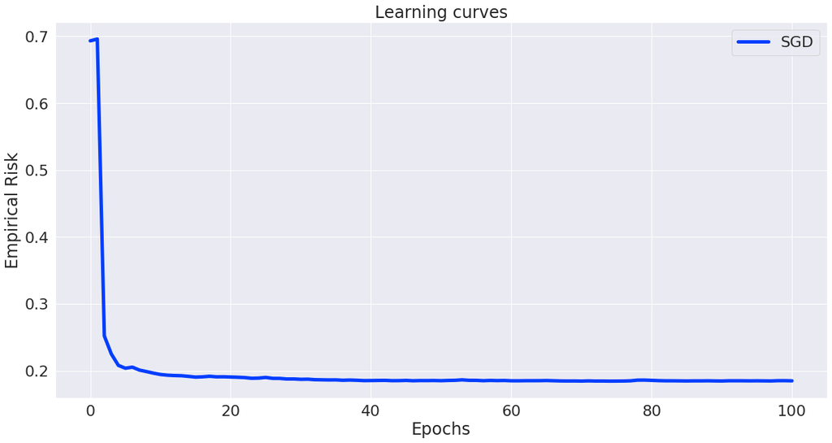

```python
clf_sgd = LogisticRegression(solver='sgd', l2=0.01, max_iter=100*len(b_train))
clf_sgd.fit(A_train, b_train)

learning_curve(SGD=clf_sgd)
```

# SAGA (Stochastic Average Gradient "Amélioré")

SAGA starts by computing a single batch gradient, then at iteration k, the following update is executed:

$$ \begin{cases} i \textrm{ chosen randomly in } \{1...n\}\\ x_{k+1} \leftarrow x_{k} - \gamma_k\big(\nabla f_i(x_k) - \alpha_i + \bar{\alpha}\big) \\ \alpha_i \leftarrow \nabla f_i(x) \end{cases} $$

where $(\alpha_j)_{j=1}^n$ are gradients evaluated at previous iterates and $\bar{\alpha}=\frac{1}{n}\sum^n_{j=1}\alpha_j$.

**Question:**

- What stepsize $\gamma_k$ ensures the convergence of this algorithm and under what assumptions?
- Complete **TODO (6)**
- Add your code to **\lib\solvers.py**.

> **Answer:**

> SAGA can achieve a linear rate of convergence when minimizing a strongly convex loss function with $$\gamma = \frac{1}{2(\mu n + L)}$$ where $\mu$ is the strong convexity constant and L the Lipschitz constant.

> If $\mu$ is not known, then the stepsize can instead be chosen to be $\gamma = \frac{1}{3 L}$ and a similar convergence result can be established.

```python
def SAGA(x0, grad, max_iter, n, L, mu):
    x = x0
    x_tab = np.copy(x0)
    stepsize = 1 / (2*(mu*n+L))
    grad_tab = grad(x,0)

    for i in range(1, n) :
        grad_tab = np.vstack((grad_tab, grad(x, i)))

    for k in range(max_iter):
        j = np.random.randint(n)
        grad_j =  grad(x,j)
        gk = grad_j - grad_tab[j] + sum(grad_tab)/n
        grad_tab[j] = grad_j
        x = x - stepsize * gk

        if k%n == 0: # each completed epoch
            x_tab = np.vstack((x_tab, x))

    return x, x_tab
```

**Question:** Run the code below to test your code.

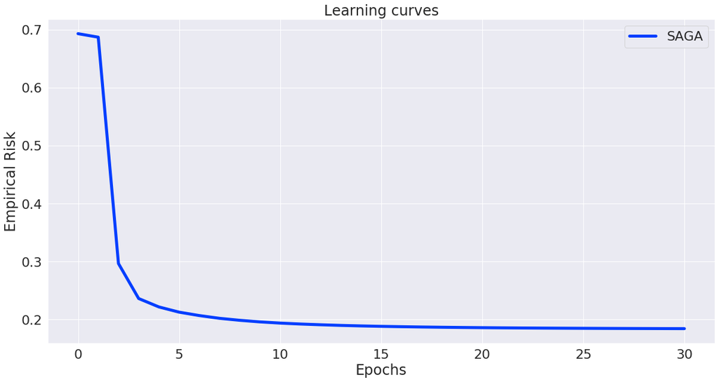

```python
clf_saga = LogisticRegression(solver='saga', l2=0.01, max_iter=30*len(b_train))
clf_saga.fit(A_train, b_train)

learning_curve(SAGA=clf_saga)
```

# SVRG (Stochastic Variance Reduced Gradient)

At iteration k of the SVRG algorithm, we perform the following:

$$ \begin{cases} \textrm{Compute the batch gradient } \nabla f(x_k)\\ \textrm{Initialise }y_0 = x_k\\ \textrm{for m in 0...M-1: } \begin{cases} i \textrm{ chosen randomly in } \{1...n\} \\ y_{m+1} \leftarrow y_{m} - \gamma_k\big(\nabla f_i(y_m) - \nabla f_i(x_k) + \nabla f(x_k)) \end{cases}\\ x_{k+1} \leftarrow y_{M} \end{cases} $$

**Question:**

- What stepsize $\gamma_k$ ensures the convergence of this algorithm and under what assumptions?
- Complete **TODO (7)**
- Add your code to **\lib\solvers.py**.

> **Answer:**

> In terms of the effect of the update frequency $M$ on the convergence, it is proved in the SVRG paper that geometric convergence of the expectation is achieved under the condition that
> $$\frac{1}{\mu L(1-2L\gamma)M}+\frac{2L\gamma}{1-2L\gamma}<1$$
> which for the stepsize specified above implies that $M$ must be greater than $L/\mu$.

```python
def SVRG(x0, grad, max_iter, n, L, mu):
    stepsize = 0.1/L
    M = int(1.1*L/mu)

    x_tab = np.array(x0, ndmin = 2)

    for k in range(max_iter):
        batch_grad = grad(x_tab[k])
        y = x_tab[k]

        for j in range(M):
            i = np.random.randint(n)
            g_j = grad(y,i) - grad(x_tab[k],i) + batch_grad
            y = y - stepsize * g_j

        x = y

        x_tab = np.vstack((x_tab, x))

    return x, x_tab
```

**Question:** Run the code below to test your code.

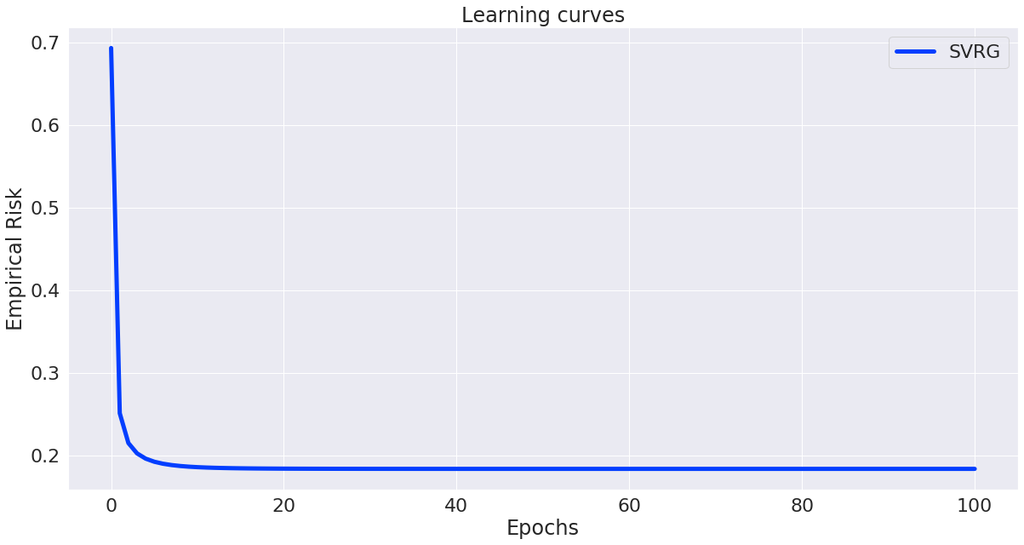

```python
clf_svrg = LogisticRegression(solver='svrg', l2=0.01, max_iter=100)
clf_svrg.fit(A_train, b_train)

learning_curve(SVRG=clf_svrg)
```

# Comparison

**Question:** Run the code below to compare all the methods you've implemented.

```python
epochs = 50
n = len(b_train)

clf_gd   = LogisticRegression(solver='gd', l2=0.01, max_iter=epochs)
clf_sgd  = LogisticRegression(solver='sgd', l2=0.01, max_iter=epochs*n)
clf_saga = LogisticRegression(solver='saga', l2=0.01, max_iter=epochs*n)
clf_svrg = LogisticRegression(solver='svrg', l2=0.01, max_iter=epochs)

clf_gd.fit(A_train, b_train)
clf_sgd.fit(A_train, b_train)
clf_saga.fit(A_train, b_train)
clf_svrg.fit(A_train, b_train)
```

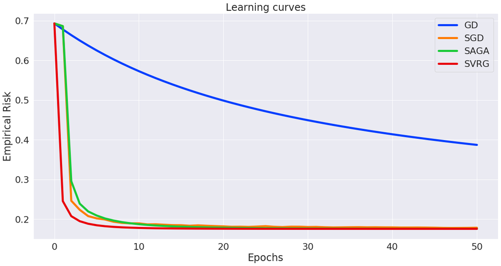

```
gd:	Accuracy on training set: 90.2%
	Accuracy on testing set:  89.9%
sgd:	Accuracy on training set: 94.6%
	Accuracy on testing set:  90.9%
saga:	Accuracy on training set: 94.9%
	Accuracy on testing set:  89.9%
svrg:	Accuracy on training set: 94.9%
	Accuracy on testing set:  89.9%
```

```python
learning_curve(GD=clf_gd, SGD=clf_sgd, SAGA=clf_saga, SVRG=clf_svrg)

for clf, name in zip([clf_gd, clf_sgd, clf_saga, clf_svrg], ['gd', 'sgd', 'saga', 'svrg']):
    print(name + ':' \
          + "\tAccuracy on training set: {0:0.1f}%".format(100*clf.score(A_train, b_train)))
    print("\tAccuracy on testing set:  {0:0.1f}%".format(100*clf.score(A_test, b_test)))
```

# IV. Regularization

**Question:**

- Rewrite the empirical risk minimization objective with both $L_1$ and $L_2$ regularization (with coefficients $l_1$ and $l_2$).
- Is this objective $\mu$-strongly convex, $L$-smooth, differentiable?
- Complete the **TODO (8)** to account for the new term in the objective.
- Add your code to **lib/linear_model.py**.

> $L_2$ regularisation, or Ridge regularisation, is the same idea using the 2-norm - the coefficient $l_2$ in this case is divided by 2 for a neater expression of the derivative: $$\underset{x\in\mathbb{R}^d}{\min}f(x)=\underset{x\in\mathbb{R}^d}{\min}\frac{1}{n}\sum_{i=1}^nf_i(x,h(a_i,b_i))+\frac{l_2}{2}||x||_2^2$$ The $L_2$-regularised objective function is strongly convex, differentiable and at most $(L+l_2)$-smooth.

```
self._empirical_risk = lambda x: sum(self._logistic_loss(A, b, x))/n \
                                 + self.l2/2.0 * np.linalg.norm(x,2) \
                                 + self.l1 * np.linalg.norm(x,1)
```

The minimization algorithms we've implemented have a slow rate of convergence for this new objective function. We will therefore use *proximal* variations of these algorithms.

**Question:** Using the $\textrm{prox}_{l_1 \|\cdot\|_1}$ operator, write down the $k^{th}$ step of proximal GD, proximal SGD, proximal SAGA, and proximal SVRG.

> **Answer:** In general, the proximal version of a gradient descent algorithm on a function $f(x)+g(x)$ performs the update step by applying the operator $\operatorname{prox}_g$ to the non-proximal update step applied to $f(x)$: $$x_{k+1}=\operatorname{prox}_{\gamma_kg}\left(x_k-\gamma_k\nabla f(x_k)\right)$$ Here we consider logistic regression objective functions with both $L_1$ and $L_2$ regularisation, and we take the proximal operator with respect to the $L_1$ regularisation term, thus $$f(x)=\log\left(1+\exp\{-b_i\langle a_i,x\rangle\}\right)+\frac{l_2}{2}||x||_2^2,\mspace{9mu}g(x)=l_1||x||_1$$

> The following are the update rules for the proximal versions of the algorithms studied so far;

> **Proximal GD:**$\mspace{9mu}x_{k+1}=\operatorname{prox}_{\gamma l_1||\cdot||_1}(x_k-\gamma\nabla f(x_k))$

> **Proximal SGD:** $\left\lbrace\begin{array}{l}\text{randomly select }i\in\{1,\ldots,n\}\\x_{k+1}=\operatorname{prox}_{\gamma_kl_1||\cdot||_1}(x_k-\gamma_k\nabla f_i(x_k))\end{array}\right.$

> **Proximal SAGA:** $\left\lbrace\begin{array}{l}\text{randomly select }i\in\{1,\ldots,n\}\\x_{k+1}=\operatorname{prox}_{\gamma_kl_1||\cdot||_1}\left(x_k-\gamma_k(\nabla f_i(x_k)-\alpha_i+\frac{1}{n}\sum_{j=1}^n\alpha_j\right)\\\alpha_i=\nabla f_i(x_k)\end{array}\right.$

> **Proximal SVRG:** $\left\lbrace\begin{array}{l}\text{calculate }\nabla f(x_k)\\\text{set }y_0=x_k\\\text{for }m\text{ from 0 to }M-1:\\\mspace{24mu}\text{randomly select }i\in\{1,\ldots,n\}\\\mspace{24mu}y_{m+1}=\operatorname{prox}_{\gamma_kl_1||\cdot||_1}\left[y_m-\gamma_k\left(\nabla f_i(y_m)-\nabla f_i(x_k)+\nabla f(x_k)\right)\right]\\x_{k+1}=y_M\end{array}\right.$

**Question:**

- Give a closed-form expression of $\textrm{prox}_{l_1 \|\cdot\|_1}$
- Complete **TODO (9)** (note that you can access the $l_1$ coefficient using **self.l1**).
- Add your code to **\lib\linear_model.py**.

> **Answer:** The proximal operator of the $L_1$-regularisation term is also known as the soft-thresholding operator:

> $$\left(\operatorname{prox}_{l_1||\cdot||_1}(x)\right)_i=\left\lbrace\begin{array}{cl}x_i-l_1&\text{if}\mspace{9mu}x_i>l_1\\0&\text{if}\mspace{9mu}|x_i|\leq l_1\\x_i+l_1&\text{if}\mspace{9mu}x_i<-l_1\end{array}\right.$$

> In the gradient descent situation we are dealing with, the $l_1$ term above will be multiplied by the stepsize.

```python
def prox(x, stepsize):
    res = []
    c = stepsize * self.l1
    for xi in x:
        if xi < -c:
            res.append(xi + c)
        elif abs(xi) <= c:
            res.append(0)
        else:
            res.append(xi - c)
    return np.array(res)
```

**Question:**

- Add **prox** to the attributes of the solvers (both in the call to **self.solver** in **/lib/linear_model.py** and in **/lib/solvers.py**) as follows:  
  solver(x0, grad, **prox**, self.max_iter, n, L, mu)
- Add a proximal step to all the algorithms in **/lib/solvers.py**.
- Paste one of these algorithms in the cell bellow.

```python
def GD(x0, grad, prox, max_iter, n, L, mu):
    stepsize  = 1.0 / L
    x         = x0
    x_tab     = np.copy(x)

    if prox is None:
        for k in range(max_iter):
        x     = x - stepsize * grad(x)
        x_tab = np.vstack((x_tab, x))

    else:
        for k in range(max_iter):
        x     = prox(x - stepsize * grad(x), stepsize)
        x_tab = np.vstack((x_tab, x))

    return x, x_tab
```

**Question:** If your proximal gradient descent is correctly implemented, the following cell will plot the support of the solution for various values of $l_1$.

- Interpret the plot and explain what can $L_1$ regularization be used for.

> **Answer:** The plot below has the co-ordinates of the input data $x$, i.e. the features of the learning problem, on the $y$-axis and the logarithm of various values of the constant $l_1$ scaling the $L_1$ regularisation term on the $x$-axis. Having run the gradient descent algorithm for each of these values for $l_1$, the plot shows a blue dot for each of the non-zero entries in the solution to which the algorithm converged using that value in the $L_1$ regularisation term. It can be seen that for very low values of $l_1$, all of the solution coordinates are non-zero, but the number of zeroes in the solution increases with the value of $l_1$.

> It can be deduced from this that $L_1$ regularisation can be used to promote sparsity of the solution, i.e. isolate the features that are most relevant to the problem. Because a higher value of $l_1$ means a higher penalty on the value of $x$ itself rather than just the value of the loss function evaluated at $x$, more of the values are "encouraged" to go to 0.

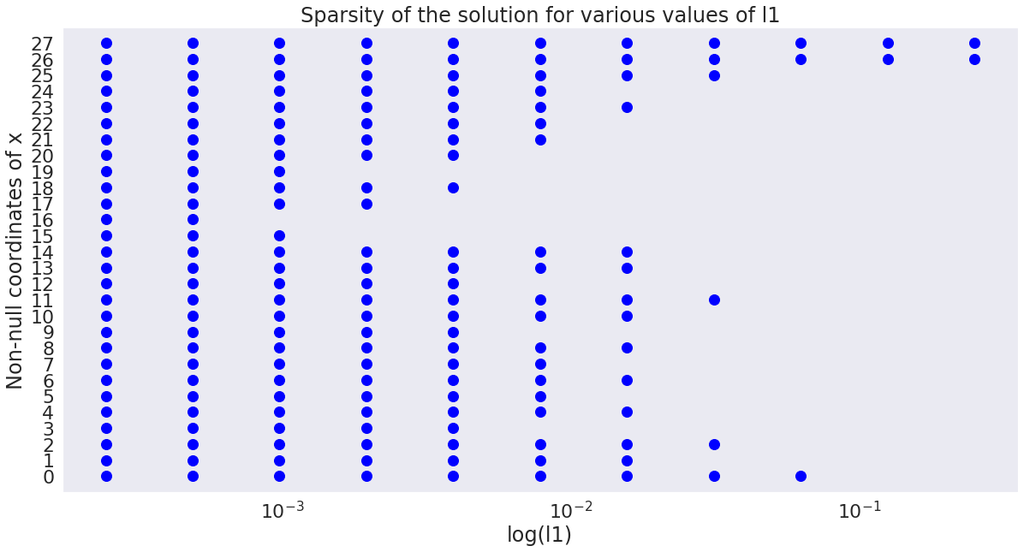

```python
from lib.visuals import l1_regularization_plot

clf = lambda l1: LogisticRegression(solver='gd', l1=l1, l2=0.1, max_iter=1000)

l1_regularization_plot(clf, A_train, b_train)
```

**Question:** The following cell will plot the value of the coordinates of the solution for various values of $l_2$.

- Interpret the plot and explain what can $L_2$ regularization be used for.

> **Answer:**

> The plot below shows the value of the solution coordinates of the logistic regression problem under consideration on the $y$-axis, and increasing values of the ridge regularisation coefficient $l_2$ on a log-scale on the $x$-axis. For each of the 28 features of the problem, a line is shown giving its evolution for different values of $l_2$. It can be observed that for lower values of $l_2$, we have a relatively sparse solution similar to those resulting from the increase in $l_1$ shown in the previous question. However, as $l_2$ is increased, all of the coordinates of the solution go to zero.

> It can be deduced from this plot that $L_2$ regularisation can be used to control the flexibility of the model, i.e. to avoid overfitting. The addition of a penalisation of the square of the updates makes the algorithm less sensitive to outliers and the fact that the objective function is strongly convex forces the minimisation problem to have a unique solution. In statistical terminology, the weights output by the gradient descent algorithm are unbiased estimators of the true predictors of the classification labels, to which we add some bias in order to reduce variance. However, if the regularisation constant is sufficiently large, the penalisation of the amplitude of the weights dominates the minimisation and they are all forced to be zero.

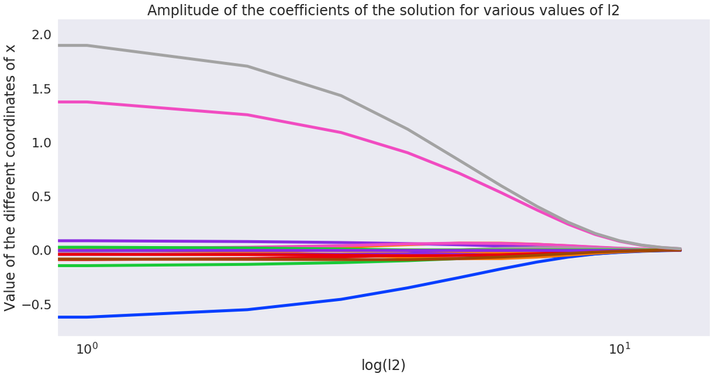

```python
from lib.visuals import l2_regularization_plot

clf = lambda l2: LogisticRegression(solver='gd', l1=0.01, l2=l2, max_iter=1000)

l2_regularization_plot(clf, A_train, b_train)
```

# V. Further development

We expect that you go beyond the lab's questions and that you develop certain aspects of your work, depending on your personal interests and skills, for instance:

- Implementations and numerical tests (further developments, more experiments, etc.)
- Applications in learning or statistics (interpretation of some results, other models, other datasets, etc.)
- Theoretical or mathematical questions (convergence proofs, convergence rates, advanced versions of an algorithm, theoretical analysis of special cases, etc.)

**Keyword ideas**: standard or stochastic Newton method, ADMM, continuation methods, tests on large scale datasets, intuition behind variance reduction, catalyst...

In this section, we present a brief discussion and simple implementation (specific to this logistic regression problem) of the following algorithms;

- Wolfe Line Search
- Newton's Method
- BFGS
- L-BFGS
- Stochastic L-BFGS

The last two algorithms in particular are too advanced for the problem we consider here, and do not go through enough iterations to perform well, but we found it interesting and instructive to try to come up with a working implementation anyway.

We also present some discussion of some interesting state-of-the-art research into feature selection methods for block gradient descent, known as the Fast Sparse Group Lasso.

## Choosing Optimal Stepsize: Line Search

One of the most pertinent questions to be addressed in the implementation of descent algorithms is that of choosing an appropriate step size at each iteration. There is always a trade-off between the extremes of an overly large step causing blow-up and an overly small step causing extremely slow convergence, and this trade-off changes its character depending on the location on the loss landscape at which we are calculating the descent direction. In this part, we will explore and implement some of the standard techniques for dealing with this issue - line search algorithms.

The idea of line search algorithms is very simple - once the descent direction $\Delta_k$ has been chosen for a point $x_k$ ($\Delta_k=\nabla f(x_k)$ for GD), the step size is what determines how far along the ray $\{x_k+\gamma_k\Delta_k|\gamma_k\geq0\}$ the next point $x_{k+1}$ will be. Ideally, we would like to minimise the value of the loss $f$ along this ray. Thus, an exact line search method would involve finding

$$\gamma_k=\underset{s\geq0}{\operatorname{argmin}}f(x_k+s\Delta_k)$$

This kind of exact search is used for certain problems in which the computational cost of this single-variable minimisation problem is low in comparison with the cost of finding the descent direction itself. However, in most cases finding the exact solution to this is intractable or just prohibitively costly, so inexact methods are used to approximate the minimum of $f$ along $\{x_k+\gamma_k\Delta_k|\gamma_k\geq0\}$, or more commonly to just reduce $f$ by "enough" along the ray, which is the approach of the method we will consider here.

### Wolfe Search

The Wolfe line search method is an efficient way of computing a step size at each iteration, which, rather than approximating the minimum of $f$ along the descent direction, just selects $\gamma_k$ such that the objective is reduced by an "acceptable" amount at the next iteration.

The *strong Wolfe conditions* comprise the following two inequalities for a stepsize $\gamma_k$ to satisfy given a descent direction $\Delta_k$. They also require the a priori choice of $(\alpha,\beta)\in\mathbb{R}^2$ such that $0<\alpha<\beta<1$;

**Armijo Condition:** $f(x_k+\gamma_k\Delta_k)\leq f(x_k)+\alpha\gamma_k\nabla f(x_k)^T\Delta_k$

**Curvature Condition:** $|\Delta_k^T\nabla f(x_k+\gamma_k\Delta_k)|\leq\beta|\nabla f(x_k)^T\Delta_k|$

```python
def wolfe_search(xk, f, grad, direction, gamma, alpha, beta):
    '''
    Parameters
    ----------
    xk: array, shape(nb_features,)
        Current update point of the descent algorithm
    f: function
        Objective function we aim to minimise
    grad: function
        Gradient of the objective function
    direction: array, shape(np_features,)
        Descent direction calculated at the previous iteration
    gamma: float
        Stepsize from the previous iteration
    alpha: float
        Constant used to check the Armijo condition - must be between 0 and 1
    beta: float
        Constant used to check the curvature condition and to update the stepsize
        - must be between 0 and 1

    Returns
    -------
    new_gamma: float
        Chosen stepsize
    '''
    new_gamma = gamma
    grad_dir_product = np.dot(grad(xk), direction)
    while f(xk + new_gamma * direction) > f(xk) + alpha * new_gamma * grad_dir_product\
        or abs(np.dot(direction, grad(xk + new_gamma * dir))) <= beta * abs(grad_dir_product):
            new_gamma *= beta

    return new_gamma
```

## Newton's Method

In this section we will first explore the most well-known second-order steepest-descent algorithm, Newton's method. Instead of the gradient descent step used in all the previous algorithms, this method uses what is known as the Newton step to find the descent direction at each iteration. This involves multiplying the gradient by the inverse of the Hessian matrix. For a twice-differentiable loss function $f$, the update step of Newton's method is

$$x_{k+1}=x_k+\gamma_k\Delta_N(x_k)$$

```
where
```

$$\Delta_N(x)=-\left[\nabla^2f(x)\right]^{-1}\nabla f(x)$$

There are several ways to motivate/interpret this method, but one of the most instructive is to look at it as the minimiser of the second-order Taylor approximation of the loss function in the neighbourhood of $x$, which is

$$f(x+h)\simeq f(x)+\nabla f(x)^Th+\frac{1}{2}h^T\nabla^2f(x)h$$

Minimising the above with respect to $h$ gives $\Delta_N$:

\begin{eqnarray} \nabla_hf(x+h) & = & \nabla f(x)+h^T\nabla^2f(x) \nonumber \\ \nabla_hf(x+h)=0\mspace{9mu}\Rightarrow\mspace{9mu}h & = & -\nabla^2f(x)^{-1}\nabla f(x) \nonumber \end{eqnarray}

Because the second-order approximation is a convex quadratic in $h$ minimised by $\Delta_N(x)$, it follows that $\Delta_N(x)$ is what should be added to $x$ to minimise the second-order approximation of $f$ at $x$. The second order approximation is essentially a quadratic model of the loss - if $f$ itself is quadratic, then $x+\Delta_N(x)$ is its exact minimiser, and the closer $f$ is to being quadratic, the better an estimate it is. Intuitively, because $f$ is twice differentiable, the quadratic model should be reasonably accurate when evaluated at $x$ close to the true minimiser $x^*$ of $f$, so the closer $x$ is to $x^*$, the better an approximation $x+\Delta_N(x)$ is of $x^*$.

Another important property of the Newton method is that the descent step $\Delta_N$ is independent of linear transformations:

$$x=Ty\mspace{9mu}\Leftrightarrow\mspace{9mu}x+\Delta_N(x)=T(y+\Delta_N(y))$$

**Convergence:** Under the assumptions that $f$ is twice continuously differentiable and $\mu$-strongly convex and its Hessian is $L$-Lipschitz continuous on the domain of $f$:

$$||\nabla^2f(x)-\nabla^2f(y)||_2\leq L||x-y||_2$$

it can be shown that there exist numbers $0<\eta<m^2/L$ and $\xi>0$ such that;

- If $||\nabla f(x_k)||_2\geq\eta$, then $f(x_{k+1})-f(x_k)\leq-\xi$
- If $||\nabla f(x_k)||_2<\eta$, then the line search will select $\gamma_k=1$ and $$\frac{L}{2m^2}||\nabla f(x_{k+1})||_2\leq\left(\frac{L}{2m^2}||\nabla f(x_{k+1})||_2\right)^2$$

The first condition above simply guarantees a particular decrease in the loss at each iteration, while the second condition tell us that after a certain point, the convergence of the algorithm is quadratic. This can be seen via recursive arguments; because $\eta<m^2/L$,

$$||\nabla f(x_k)||_2<\eta\mspace{12mu}\Rightarrow\mspace{12mu}||\nabla f(x_{k+1})||_2<\eta$$

i.e. once the condition on the 2-norm of $f$ is satisfied for some iterate $k$, it is satisfied for all subsequent iterates $l\geq k$, and therefore we can apply the consequent inequality recursively to find that

$$\frac{L}{2m^2}||\nabla f(x_l)||_2\leq\left(\frac{1}{2}\right)^{2^{l-k}}\mspace{12mu}\forall l\geq k$$

and hence

$$f(x_l)-f(x^*)\leq\frac{1}{2m}||\nabla f(x_l)||_2^2\leq\frac{2m^3}{L^2}\left(\frac{1}{2}\right)^{2^{l-k+1}}$$

**Stopping Criterion:** Here we define a term known as the *Newton decrement*:

$$\lambda(x)=\sqrt{\nabla f(x)^T\nabla^2f(x)^{-1}\nabla f(x)}$$

This is used for the constant in the backtracking line search for Newton's method:

$$\nabla f(x)^T\Delta_N(x)=\lambda(x)^2$$

and it can be interpreted as the directional derivative of $f$ at $x$ in the direction of $\Delta_N(x)$:

$$\lambda(x)^2=\nabla f(x)^T\Delta_N(x)=\left.\left(\frac{d}{d\gamma}f(x+\gamma\Delta_N(x))\right)\right|_{\gamma=0}$$

The stopping criterion we will use in our implementation is $\lambda(x_k)^2/2\leq\epsilon$ for some chosen precision $\epsilon$.

At each iteration $k$, the algorithm performs the following steps;

1. Compute $\Delta(x_k)$ and $\lambda(x_k)$
2. **If** $\lambda(x_k)^2/2\leq\epsilon$ : stop.
3. Choose $\gamma_k$ via line search
4. Update $x_{k+1}=x_k+\gamma_k\Delta(x_k)$

To implement Newton's method, we first add an oracle for the Hessian, shown below.

```python
def hess(x, i=None):
    '''
    Hessian of the objective function at x. The parameter i behaves in
    the same way as it does for the gradient function.
    '''
    if i is None:
        output = np.empty((d,d))
        for i in range(n):
            expterm = np.exp(-b[i] * np.dot(A[i,:], x))
            output += np.outer(A[i,:], A[i,:]) * (expterm/((1+expterm)**2))
        output /= n
        output += self.l2 * np.eye(d)

    else:
        expterm = np.exp(-b[i] * np.dot(A[i], x))
        output += np.outer(A[i,:], A[i,:])
        output *= expterm/((1+expterm)**2)

    return output
```

This oracle is then used in the algorithm implementation, which was added to the solvers of the linear regression class.

```python
def newton(x0, f, grad, hess, max_iter, n, L, eps):
    '''
    Implementation of Newton's method for logistic regression.

    Parameters
    ----------
    x0: array, shape (nb_features,)
        Initial point for the solver
    f: function
        Objective function - to be passed to line search
    grad: function
        Gradient of the objective function
    hess: function
        Hessian matrix of the objective function
    max_iter:
        Number of epochs after which the algorithm will stop if convergence is
        not achieved.
    n: int
        Dataset size
    L: float
        Smoothness constant of the objective function
    eps: float
        Desired precision of the algorithm to be used in the stopping rule

    Returns
    -------
    x: array, shape (nb_features,)
        Final iterate of the solver
    x_tab: array, shape (nb_features, max_iter)
        table of all the iterates
    '''
    x = x0
    x_tab = np.copy(x)
    stepsize = 1.0

    for k in range(max_iter):
        g = grad(x)
        H = hess(x)
        direction = np.linalg.solve(H, g)
        stepsize = line_search.wolfe_search(x, f, grad, direction, stepsize, 0.1, 0.9)
        x = x - stepsize * direction
        x_tab = np.vstack((x_tab, x))

        decrement = np.dot(g, direction)
        if(decrement/2 <= eps):
            break

    return x, x_tab
```

```python
clf_newton = LogisticRegression(solver='newton', l2=0.01, max_iter=100)
clf_newton.fit(A_train, b_train)
clf_newton.score(A_train, b_train)
```

## Quasi-Newton Method (BFGS)

While the Newton method performs very well with respect to the number of gradient steps it requires, it does not scale well with the dimension of the problem - the storage cost of the Hessian at each iteration is $\mathcal{O}(d^2)$ for a problem with $f:\mathbb{R}^d\to\mathbb{R}$. To deal with this issue, various so-called *Hessian-free* methods have been developed, including subsampling-based approaches and the one we will consider here, the Broyden-Fletcher-Goldfarb-Shanno (BFGS) scheme. This scheme follows the same structure as Newton's method, while replacing the Hessian with an approximation term that uses only gradient information. The update step is

$$x_{k+1}=x_k-\gamma H_k\nabla f(x_k)$$

where $H_k$ is the approximation to the inverse of the Hessian; defining the displacement terms $s_k=x_{k+1}-x_k$ and $y_k=\nabla f(x_{k+1})-\nabla f(x_k)$, it is updated iteratively as

$$H_{k+1}=\left(I-\frac{y_ks_k^T}{s_k^Ty_k}\right)^TH_k\left(I-\frac{y_ks_k^T}{s_k^Ty_k}\right)+\frac{s_ks_k^T}{s_k^Ty_k}$$

$$H_{k+1}=H_k-\frac{s_ky_k^TH_k+H_ky_ks_k^T}{y_k^Ts_k}+\left(1+\frac{y_k^TH_ky_k}{y_k^Ts_k}\right)\frac{s_ks_k^T}{y_k^Ts_k}$$

A limitation of this method in practice is that $H_k$ is always dense, even when the exact Hessian is sparse. This means that it does not perform well on very large problems. A very effective way to address this is the *limited-memory* version, or L-BFGS, which we will discuss next.

```python
def BFGS(x0, grad, max_iter, n, L):
    x = x0
    x_tab = np.copy(x)
    H = np.eye(x0.size)
    stepsize = 1.0 / L

    for k in range(max_iter):
        g = grad(x)
        x_prev = np.copy(x)

        x = x - stepsize * np.dot(H,g)

        s = x - x_prev
        y = grad(x) - g
        den = np.dot(y,s)

        H = H - (np.dot(np.outer(s,y),H) + np.dot(H,np.outer(y,s))) / den +\
            (1 + np.dot(y,np.dot(H,y))/den) * (np.outer(s,s)/den)

        x_tab = np.vstack((x_tab, x))

    return x, x_tab
```

```python
clf_bfgs = LogisticRegression(solver='bfgs', l2=0.01, max_iter=100)
clf_bfgs.fit(A_train, b_train)
clf_bfgs.score(A_train, b_train)
```

```
0.9425675675675675
```

## L-BFGS

Like the original, L-BFGS uses an estimate of the inverse Hessian, but in order to limit the storage cost of the algorithm, it uses an implicit representation of the update term which requires only a few vectors to be held in memory, which gives it a linear memory requirement and makes it much more suitable for high-dimensional problems.

L-BFGS maintains a record of the past $m$ updates of the point $x_k$ and gradient $\nabla f(x_k)$. In general, the algorithm performs well even with small $m$, something like $m<10$. Instead of storing the full matrix $H_k$, L-BFGS directly approximates the product $H_k\nabla f(x_k)$. In our implementation, we use an approach called *two-loop recursion* to update this direction vector.

For a given point $x_k$ at the $k^{\text{th}}$ iteration, we assume that we have stored the previous $m$ displacement terms $s_k$ and $y_k$ as before. We then define two length-$m$ sequences of vectors $q_{k-m},\ldots,q_k$ and $z_{k-m},\ldots,z_k$. The idea of the descent direction update is to iterate "backwards" ($k-1$ to $k-m$) to update the vectors $q_i$ and then "forwards" ($k-m$ to $k-1$) over the $z_i$, with $z_k$ then being the descent direction. The backward-loop vectors are defined as

$$q_i=\left(I-\frac{y_is_i^T}{y_i^Ts_i}\right)q_{i+1}$$

and the forward-loop vectors as

$$z_i=-H_iq_i$$

Therefore the updates operate as follows;

- Initialisation $q=\nabla f(x_k)$
- for $i$ from $k-1$ to $k-m$: $a_i=\frac{s_i^Ty_i}{y_i^Ts_i}q,\mspace{12mu}q\leftarrow q-a_iy_i$
- Initialisation $H_k^0=\frac{s_{k-1}^Ty_{k-1}}{y_{k-1}^Ty_{k-1}}I,\mspace{12mu}z=H_k^0q$
- for $i$ from $k-m$ to $k-1$: $b_i=\frac{y_i^T}{y_i^Ts_i}z,\mspace{12mu}z\leftarrow z+s_i(a_i-b_i)$

```python
def lbfgs_recursion(k, m, q, d, disp, grad_disp):
    A = {}
    for i in reversed(range(k-m, k)):
        a = q * np.dot(disp[i%m], grad_disp[i%m])/np.dot(grad_disp[i%m], grad_disp[i%m])
        q = q - a * grad_disp[i%m]
        A[i] = a
    s = disp[m-1]
    y = grad_disp[m-1]
    H = np.eye(d) * np.dot(s,y)/np.dot(y,y)
    z = np.dot(H, q)
    for i in range(k-m, k):
        b = z * (grad_disp[i%m]/np.dot(grad_disp[i%m], disp[i%m]))
        z = z + np.dot(disp[i%m], A[i] - b)

    return z

def LBFGS(x0, grad, max_iter, n, L, m):
    x = x0
    x_tab = np.copy(x)
    stepsize = 1.0 / L
    d = x0.size
    H = np.eye(d)
    z = grad(x0)

    disp = {}
    grad_disp = {}

    for k in range(max_iter):
        x_prev = np.copy(x)
        g = grad(x)

        x = x - stepsize * z

        disp[k%m] = x - x_prev
        grad_disp[k%m] = grad(x) - g

        if k < m:
            s = disp[k]
            y = grad_disp[k]
            den = np.dot(y,s)
            if den == 0:
                return x0, y

            H = H - (np.dot(np.outer(s,y),H) + np.dot(H,np.outer(y,s))) / den +\
                (1 + np.dot(y,np.dot(H,y))/den) * (np.outer(s,s)/den)

            z = np.dot(H,g)

        else:
            z = lbfgs_recursion(k, m, g, d, disp, grad_disp)

        x_tab = np.vstack((x_tab, x))

    return x, x_tab
```

```python
clf_lbfgs = LogisticRegression(solver='lbfgs', l2=0.01, max_iter=100)
clf_lbfgs.fit(A_train, b_train)
clf_lbfgs.score(A_train, b_train)
```

```
0.7871621621621622
```

## Stochastic L-BFGS

For many machine learning problems in which both the dimension $d$ and the training data size $n$ are both very large, even L-BFGS does not scale well and stochastic variants offer better performance. However, quasi-Newton updates are qualitatively different from other first-order optimisation methods in that they are inherently a process of overwriting updates rather than accumulating them. Thus, L-BFGS does not immediately lend itself to a stochastic version - unlike in SGD and its variants, where the stochastic updates average together over the epochs to produce an effective descent, the updates used to construct the inverse Hessian approximation in L-BFGS tend to overwrite each other, which does not guarantee an acceptable performance improvement over time. To deal with this, the stochastic gradient and stochastic curvature estimation (Hessian) are decoupled by computing the Hessian-gradient vector product approximations using mini-batches of the training data that are subsampled independently, as proposed by Byrd et al in 2014. This approach does require calculating some second-order information, in the form of the stochastic estimate of the Hessian.

The variant of stochastic L-BFGS we will implement here was proposed by Moritz et al in 2015 (appeared in AISTATS 2016). It performs L-BFGS updates using variance-reduced gradient computations, similarly to SVRG, but instead of computing the inverse Hessian based on the full dataset, it recomputes it at fixed regular intervals using only a subsample of the training data taken in the same way as in the stochastic gradient computation.

The algorithm takes six parameters; a stepsize $\gamma$, the number of stochastic updates $l$, the memory size $m$, the number of stochastic updates per update of the curvature $p$, and batch sizes $n_g$ and $n_H$ for the gradient and Hessian subsampling respectively. It proceeds as follows;

1. Initialise $r=0$, $k=0$ and $H_0=I$ *($r$ is used as an iterator to keep track of the curvature updates)*
2. Compute the full gradient $\nabla f(x_k)$
3. Set $w_0=x_k$ and $u_0=w_0$ *(this second initialisation only happens when $k=0$)*
4. For $t$ from 0 to $l-1$:
   1. Sample a mini-batch of size $n_g$ from $\{1,\ldots,n\}$
   2. Compute stochastic gradients $\mu_t^{(1)}=\frac{1}{n_g}\sum_{i=1}^{n_g}\nabla f_i(w_t)$ and $\mu_t^{(2)}=\frac{1}{n_g}\sum_{i=1}^{n_g}\nabla f_i(x_k)$
   3. Variance reduced gradient update: $w_{t+1}=w_t-\gamma H_r\left(\mu_t^{(1)}-\mu_t^{(2)}+\nabla f(x_k)\right)$
   4. If $t\equiv0\mod p$:
      1. Update $r\leftarrow r+1$
      2. Take the average of the last $p$ stochastic updates: $u_r=\frac{1}{p}\sum_{j=t-p}^{t-1}w_j$
      3. Sample a mini-batch of size $n_H$ from $\{1,\ldots,n\}$
      4. Compute displacement terms $s_r=u_r-u_{r-1}$ then $y_r=\frac{1}{n_H}\sum_{i=1}^{n_H}\nabla^2 f_i(u_r)s_r$
      5. Update $H_r$ as in L-BFGS
5. Set $x_{k+1}=w_i$ for a randomly chosen $i\in\{0,\ldots,l-1\}$
6. Update $k\leftarrow k+1$ and repeat from step 2 until convergence.

**Note:** For the purposes of this implementation, the $\texttt{grad}$ oracle was updated to deal with mini-batch gradients. Also, it is clear that this logistic regression problem is too simple for the stochastic properties of this algorithm to be effective and it does not perform well.

```python
def SLBFGS(x0, grad, hess, max_iter, L, n, l, m, p, ng, nH):
    '''
    l: int
        number of stochastic upates
    m: int
        memory size
    p: int
        number of stochastic updates per update of the curvature
    ng: int
        batch size for gradient subsampling
    nH: int
        batch size for Hessian subsampling
    '''
    x = x0
    x_tab = np.copy(x)
    stepsize = 1.0 / L
    d = x0.size
    r = 0
    H = np.eye(d)
    u = x

    disp = {}
    grad_disp = {}

    for k in range(max_iter):
        g = grad(x)
        w = x
        w_tab = np.copy(w)

        for t in range(l):
            i = list(np.random.randint(n, size = ng))
            mu1 = grad(w, i)
            mu2 = grad(x, i)

            w = w - stepsize * np.dot(H, mu1 - mu2 + g)
            w_tab = np.vstack((w_tab, w))

            if t%p == 0:
                u_prev = np.copy(u)
                u = np.mean(w_tab, 0)
                disp[r] = u - u_prev

                hess_list = []
                J = np.random.randint(n, size = nH)
                for j in J:
                    hess_list.append(hess(u,j))

                grad_disp[r] = disp[r] * np.mean(np.array(hess_list))

                if r < m:
                    s = disp[r]
                    y = grad_disp[r]
                    den = np.dot(y,s)
                    if den == 0:
                        return x0, y

                    H = H - (np.dot(np.outer(s,y),H) + np.dot(H,np.outer(y,s))) / den +\
                        (1 + np.dot(y,np.dot(H,y))/den) * (np.outer(s,s)/den)

                else:
                    H = lbfgs_recursion(r, m, grad(u), d, disp, grad_disp)

                r += 1

        update_index = np.random.randint(l)
        x = w_tab[update_index]

    return x, x_tab
```

```python
clf_slbfgs = LogisticRegression(solver='slbfgs', l2=0.01, max_iter=100)
clf_slbfgs.fit(A_train, b_train)
clf_slbfgs.score(A_train, b_train)
```

## Fast Sparse Group Lasso

Finally, we present the main ideas of a paper titled "Fast Sparse Group Lasso" [Ida, Fujiwara & Kashima, 2019], presented in NeurIPS 2019. It shows a methodology useful when we have Sparse Grouped data. We have chosen this method because it takes the concepts of Lasso and Block Coordinate Descent, that it is an alternative minimization method. Also, we find enriching to get an approach to a new development presented in one of the major conferences.

Sparse Group Lasso (SGL) is a feature-selection method for a linear regression model when data have a grouped structure. It is useful when we want to identify group of features that have relationship with the response. As an example it has application in gene expression data and climate data. SGL finds such groups and features by obtaining sparse parameters for the linear regression model.

The Block Coordinate Descent (BCD) is used to obtain the sparse parameters in SGL. Nevertheless, it suffers from high computation costs. Therefore this paper proposes a fast BCD for the Sparse Group Lasso. The main idea is to identify the groups whose parameters must be zeros by only using the parameters in the group, whereas the standard BCD method uses all the parameters or data points. As the number of parameters in one group is much smaller than the total number of parameters or data points, this method efficiently skips the computation of group whose parameters must be zeros. One important point of this method is that it does not need any additional hyper-parameter. The experiments shown in the paper achieve the same prediction error of the original BCD in less time.

The Sparse Group Lasso method for linear regression finds small sets of groups in addition to the predictor variables that achieve high prediction accuracy. It finds a solution with few nonzero entries in $\beta$. Suppose, further,that our predictor variables were divided into *G* different groups. We are given these group memberships and rather than just sparsity in $\beta$ we would like a solution which uses only a few of the groups. The problem can be formalized in the following way: $$ \hat{\beta}=\underset{\beta \in \mathbb{R}^{p}}{\arg \min } \frac{1}{2 n} || y- \sum_{g=1}^{G} X^{(g)} \beta^{(g)}||_{2} ^{2} +(1-\alpha) \lambda \sum_{g=1}^{G} \sqrt{p_{g}}|| \beta^{(g)}\left\|_{2}+\alpha \lambda\right\| \beta \|_{1} $$

Where $n$ is the number of data points, where each data point is represented as a $p$ -dimensional feature vector, $y \in \mathbb{R}^{n}$ be a continuous response, and $G$ be the total number of feature groups. A matrix of features $X \in \mathbb{R}^{n \times p}$ is represented as $X=\left[X^{(1)}, X^{(2)}, \ldots, X^{(G)}\right],$ where $X^{(g)} \in \mathbb{R}^{n \times p_{g}}$ is the block matrix of $X$ corresponding to the $g$ -th feature group with the number of features $p_{g} .$ Similarly, parameter vector $\beta \in \mathbb{R}^{p}$ is represented as $\beta=\left[\beta^{(1) \mathrm{T}}, \beta^{(2) \mathrm{T}}, \ldots, \beta^{(G) \mathrm{T}}\right]^{\mathrm{T}},$ where $\beta^{(g)} \in \mathbb{R}^{p_{g}}$ is the parameter (coefficient) vector of group $g .$ Therefore, the linear regression model in SGL is represented as $y=X \beta=X^{(1)} \beta^{(1)}+\cdots+X^{(G)} \beta^{(G)} .$ And $\alpha \in[0,1]$ and $\lambda \geq 0$ are regularization constants; $\alpha$ decides the balances of the convex combination of $l_{1}$ and $l_{2}$ norm penalties and $\lambda$ controls the degree of sparsity of the solution.

**The main ideas proposed:**

1. Identify groups whose parameter vectors must be zero vectors by approximating the equation $\left\|S\left(X^{(g) T} r_{(-g)}, \alpha \lambda\right)\right\|_{2} \leq \sqrt{p_{g}}(1-\alpha) \lambda$ of the BCD, which checks whether the parameter vector of each group is a zero. Where $r_{(-g)}$ is the partial residual and is defined as follows: $$ r_{(-g)}=y-\sum_{l \neq g}^{G} X^{(l)} \beta^{(l)}$$ $S(\cdot)$ is the coordinate-wise soft-threshold operator; the $j$ -th element is computed as $S(z, \gamma)[j]=$ $\operatorname{sign}(z[j])(|z[j]|-\gamma)_{+} $

   The fast BCD computes an upper bound of $\left\|S\left(X^{(g) T} r_{(-g)}, \alpha \lambda\right)\right\|_{2}$ instead of computing the exact value. So, if the upper bound is lower than $\sqrt{p_{g}}(1-\alpha) \lambda$, the parameter vector of the group must be a zero vector. The result of doing this approximation is that we skip the computation of the group. The upper bound requires only $O(p_g)$ time instead of the $O(pp_g + p^{2}_g)$ or $O(np_g)$ time for the original equation. As a consequence it reduces the computation cost.
2. The second idea is to extract a \textit{candidate group set}, which contains groups whose parameter vectors must **not** be zero vectors. As the parameters in the set are likely to largely contribute to the prediction, is expected that BCD to effectively optimize the objective function by preferentially updating the parameters in the set.

Number of computations: $$\begin{array}{lll} {\textbf { Dataset }} & {\textbf{Original BCD}} & {\textbf{Fast BCD}} \\ \hline {\text { abalone }} & {1.141 \times 10^{5}} & {3.168 \times 10^{3}} \\ {\text { cpusmall }} & {2.105 \times 10^{5}} & {7.768 \times 10^{4}} \\ {\text { boston }} & {1.248 \times 10^{6}} & {9.998 \times 10^{4}} \\ {\text { bodyfat }} & {1.694 \times 10^{7}} & {2.403 \times 10^{6}} \\ {\text { eunite } 2001} & {8.629 \times 10^{5}} & {2.052 \times 10^{5}} \\ {\text { pyrim }} & {7.667 \times 10^{7}} & {7.523 \times 10^{6}} \end{array} $$

# References

- Bottou, L., Curtis, F.E., Nocedal, J., *Optimization Methods for Large-Scale Machine Learning*, SIAM Vol.60, 2018
- Defazio, A., Bach, F., Lacoste-Julien, S., *SAGA: A Fast Incremental Gradient Method With Support for Non-Strongly Convex Composite Objectives*, NeurIPS 2014
- Johnson, R., Zhang, T., *Accelerating Stochastic Gradient Descent using Predictive Variance Reduction*
- Boyd, S., Vandenberghe, L., *Convex Optimisation*, Cambridge University Press, 2004
- Goldfarb, D., *A Family of Variable Metric Updates Derived by Variational Means*, Mathematics of Computation, 1970
- Fletcher, R., *A New Approach to Variable Metric Algorithms*, Computer Journal, 1970
- Byrd, R. H., Lu, P., Nocedal, J., Zhu, C., *A Limited Memory Algorithm for Bound Constrained Optimisation*, SIAM Journal of Scientific Computing, 1994
- Moritz, P., Nishihara, R., Jordan, M. I., *A Linearly-Convergent Stochastic L-BFGS Algorithm*, Proc. AISTATS, 2016
- Byrd, R. H., Hansen, S. L., Nocedal, J., Singer, Y., *A Stochastic quasi-Newton method for large-scale optimisation*, 2014
- Ida Y., Fujiwara Y., Kashima H.: *Fast Sparse Group Lasso*, Advances in Neural Information Processing Systems 32 (NIPS 2019) pre-proceedings, 2019